# MIS 306 Data Analysis | Competition

## Weekly NKE Price Analysis: ARIMA Model Selection and Forecasting

Comperison of two ARIMA models for Nike’s weekly stock prices. The ARIMA(1,1,0) model shows a small negative effect (-0.1159) from the previous week’s price, with a tiny upward trend (0.0018). The ARIMA(1,1,1) model has a stronger negative effect (-0.5165) from past prices and accounts for random shocks (0.4026), with a slightly stronger trend (0.0025). Both models fit the data well, with nearly identical error levels (sigma² ≈ 0.0016). However, the ARIMA(1,1,1) performs slightly better, with a lower AIC (-3448.91 vs -3446.96) and higher log likelihood (1728.45 vs 1726.48), meaning it explains the data better despite being more complex. The small differences suggest either model could work, but the ARIMA(1,1,1) may capture more patterns in the weekly price changes.

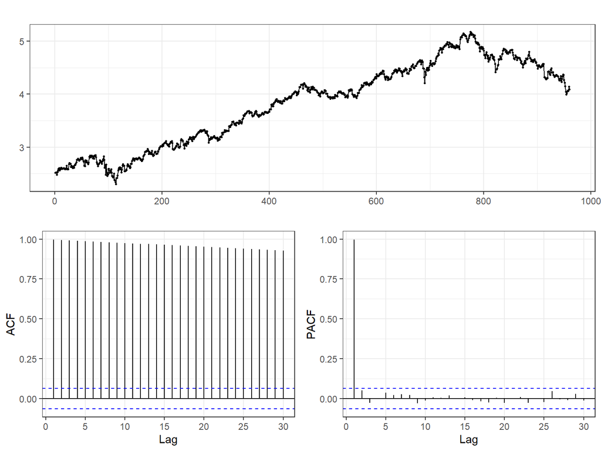

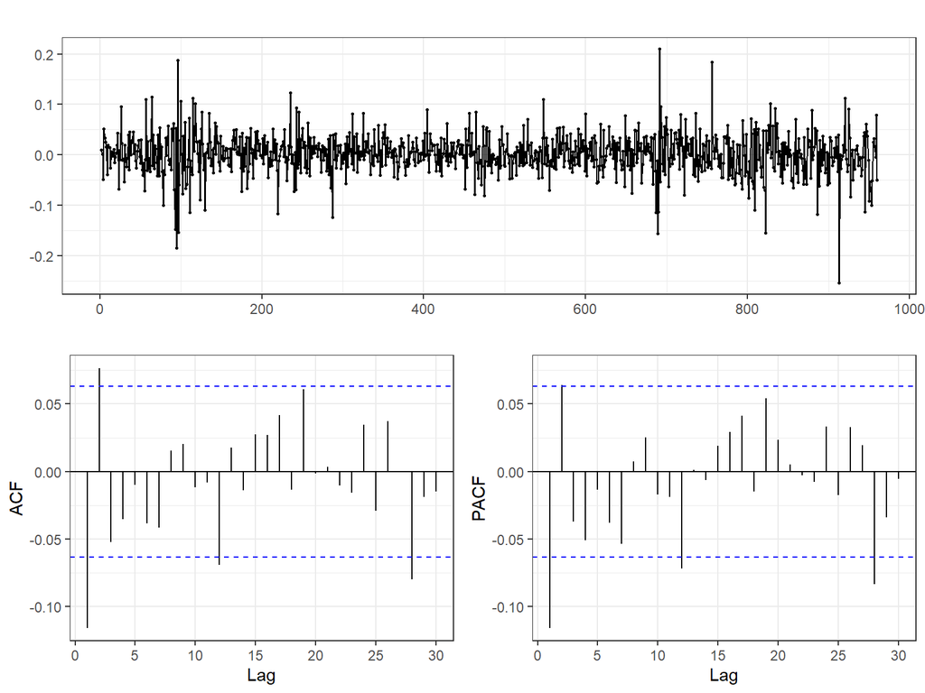

```
## Using `date` as index variable.
```

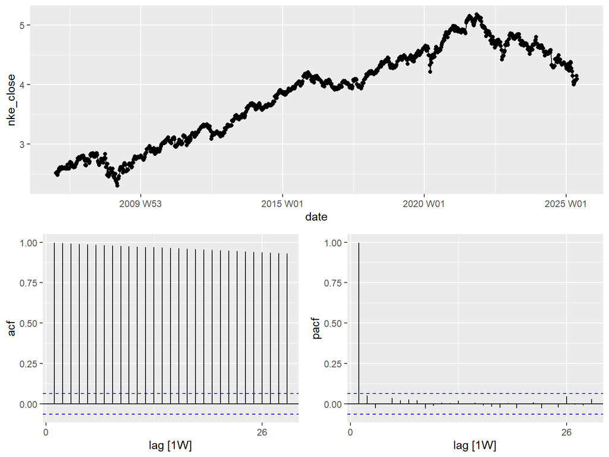